# Socio-economic data

```r
library(tidyverse)
library(janitor)
```

All economic data (except Eurostat) in this file

Survey data Families who experience difficulties with regular expenses http://dati.istat.it/Index.aspx?DataSetCode=DCCV_NOSOLDI

```r
expenses.difficult <- read.table('../Econ data/Famiglie che hanno  difficoltà nel pagamento di alcune spese - it.csv', sep = '|', header = TRUE) %>%
  clean_names()
```

Rural poverty on the rise?

[figure not shown]

Income quintiles (for income distribution, inequalities) http://dati.istat.it/Index.aspx?DataSetCode=DCCV_QUINTOREDD

```r
income.quintiles <- read.table('../Econ data/Quinto di reddito equivalente - it.csv', sep = '|', header = TRUE) %>%
  clean_names() %>%
  mutate(quinto_di_reddito_equivalente = trimws(quinto_di_reddito_equivalente)) %>%
  mutate(quinto_di_reddito_equivalente = factor(quinto_di_reddito_equivalente, ordered = TRUE, levels = c('primo', 'secondo', 'terzo', 'quarto', 'quinto')))
```

50% of population in the South and Islands is in the two lowest quintiles

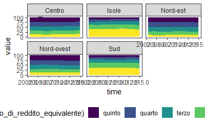

```r
income.quintiles %>%
  filter(territorio %in% c('Isole', 'Sud', 'Centro', 'Nord-est', 'Nord-ovest')) %>%
  ggplot(aes(time, value, fill = fct_rev(quinto_di_reddito_equivalente) )) + geom_area(position = 'stack') + theme_bw() +
  facet_wrap(territorio ~ .) +
  theme(legend.position = 'bottom')
```

Broad differences within macro-areas as well

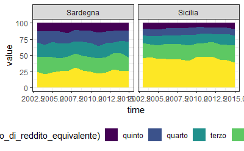

```r
income.quintiles %>%
  filter(territorio %in% c('Sardegna', 'Sicilia')) %>%
  ggplot(aes(time, value, fill = fct_rev(quinto_di_reddito_equivalente) )) + geom_area(position = 'stack') + theme_bw() +
  facet_wrap(territorio ~ .) +
  theme(legend.position = 'bottom')
```

Data on household income (ISTAT) http://dati.istat.it/Index.aspx?DataSetCode=DCCV_REDNETFAMFONTERED

```r
income.data <- read.table('../Econ data/DCCV_REDNETFAMFONTERED - Reddito netto - intero ds.csv', sep = '|', header = TRUE) %>%
  clean_names()
```

```r
glimpse(income.data)
```

```
Observations: 22,120
Variables: 31
$ i_it107                                                                 <fct> IT, IT, ...
$ territorio                                                              <fct> Italia, ...
$ t_d8                                                                    <fct> REDD_MED...
$ tipo_dato                                                               <fct> reddito ...
$ m1                                                                      <int> 9, 9, 9,...
$ misura                                                                  <fct> valori a...
$ praf                                                                    <int> 1, 1, 1,...
$ presenza_affitti_imputati                                               <fct> inclusi ...
$ rdpr                                                                    <int> 9, 9, 9,...
$ fonte_principale_di_reddito_familiare                                   <fct> totale, ...
$ n_comp                                                                  <int> 99, 99, ...
$ numero_di_componenti                                                    <fct> totale, ...
$ tip_fam1                                                                <int> 99, 99, ...
```

[output cut: 18 more lines]

Considering median income (more robust than mean) by macro-region (no gender/age/etc breakdown)

```r
income.data %>%
  filter(territorio %in% c('Nord-ovest', 'Nord-est', 'Centro', 'Sud', 'Isole', 'Italia')) %>%
  filter(condizione_professionale_prevalente_nell_anno_del_principale_percettore == 'totale' & titolo_di_studio_del_principale_percettore == 'totale' & fonte_principale_di_reddito_familiare == 'totale' & numero_di_anziani_in_famiglia == 'totale' & numero_di_minori_in_famiglia == 'totale' & classe_di_et_a_del_principale_percettore == 'totale' & sesso_del_principale_percettore == 'totale' & tipologia_familiare == 'totale' & numero_di_componenti == 'totale' ) -> income.tots

income.tots %>%

  filter(grepl('mediano', tipo_dato)) -> income.tots.median

income.tots %>%
  filter(grepl('medio', tipo_dato)) -> income.tots.mean


income.tots.median %>%
  arrange(time, presenza_affitti_imputati, -value) %>%
  filter(territorio %in% c('Sud', 'Isole', 'Italia'))
```

| i_it107 | territorio | t_d8 | tipo_dato | m1 | misura | praf | presenza_affitti_imputati | rdpr | fonte_principale_di_reddito_familiare | n_comp | numero_di_componenti | tip_fam1 | tipologia_familiare | tip_fam_min | numero_di_minori_in_famiglia | tip_fam_anz | numero_di_anziani_in_famiglia | sex1 | sesso_del_principale_percettore | eta1 | classe_di_et_a_del_principale_percettore | tit_st | titolo_di_studio_del_principale_percettore | con_d2 | condizione_professionale_prevalente_nell_anno_del_principale_percettore | time | seleziona_periodo | value | flag_codes | … |
| --- | --- | --- | --- | --- | --- | --- | --- | --- | --- | --- | --- | --- | --- | --- | --- | --- | --- | --- | --- | --- | --- | --- | --- | --- | --- | --- | --- | --- | --- | --- |
| IT | Italia | REDD_MEDIANO_FAM | reddito mediano annuale delle famiglie (in euro) | 9 | valori assoluti | 2 | esclusi fitti imputati | 9 | totale | 99 | totale | 99 | totale | 9 | totale | 9 | totale | 9 | totale | TOTAL | totale | 99 | totale | 99 | totale | 2003 | 2003 | 21635 |  | … |
| ITF | Sud | REDD_MEDIANO_FAM | reddito mediano annuale delle famiglie (in euro) | 9 | valori assoluti | 2 | esclusi fitti imputati | 9 | totale | 99 | totale | 99 | totale | 9 | totale | 9 | totale | 9 | totale | TOTAL | totale | 99 | totale | 99 | totale | 2003 | 2003 | 18861 |  | … |
| ITG | Isole | REDD_MEDIANO_FAM | reddito mediano annuale delle famiglie (in euro) | 9 | valori assoluti | 2 | esclusi fitti imputati | 9 | totale | 99 | totale | 99 | totale | 9 | totale | 9 | totale | 9 | totale | TOTAL | totale | 99 | totale | 99 | totale | 2003 | 2003 | 17205 |  | … |
| IT | Italia | REDD_MEDIANO_FAM | reddito mediano annuale delle famiglie (in euro) | 9 | valori assoluti | 1 | inclusi fitti imputati | 9 | totale | 99 | totale | 99 | totale | 9 | totale | 9 | totale | 9 | totale | TOTAL | totale | 99 | totale | 99 | totale | 2003 | 2003 | 26716 |  | … |
| ITF | Sud | REDD_MEDIANO_FAM | reddito mediano annuale delle famiglie (in euro) | 9 | valori assoluti | 1 | inclusi fitti imputati | 9 | totale | 99 | totale | 99 | totale | 9 | totale | 9 | totale | 9 | totale | TOTAL | totale | 99 | totale | 99 | totale | 2003 | 2003 | 22089 |  | … |
| ITG | Isole | REDD_MEDIANO_FAM | reddito mediano annuale delle famiglie (in euro) | 9 | valori assoluti | 1 | inclusi fitti imputati | 9 | totale | 99 | totale | 99 | totale | 9 | totale | 9 | totale | 9 | totale | TOTAL | totale | 99 | totale | 99 | totale | 2003 | 2003 | 20340 |  | … |
| IT | Italia | REDD_MEDIANO_FAM | reddito mediano annuale delle famiglie (in euro) | 9 | valori assoluti | 2 | esclusi fitti imputati | 9 | totale | 99 | totale | 99 | totale | 9 | totale | 9 | totale | 9 | totale | TOTAL | totale | 99 | totale | 99 | totale | 2004 | 2004 | 22338 |  | … |
| ITF | Sud | REDD_MEDIANO_FAM | reddito mediano annuale delle famiglie (in euro) | 9 | valori assoluti | 2 | esclusi fitti imputati | 9 | totale | 99 | totale | 99 | totale | 9 | totale | 9 | totale | 9 | totale | TOTAL | totale | 99 | totale | 99 | totale | 2004 | 2004 | 19030 |  | … |
| ITG | Isole | REDD_MEDIANO_FAM | reddito mediano annuale delle famiglie (in euro) | 9 | valori assoluti | 2 | esclusi fitti imputati | 9 | totale | 99 | totale | 99 | totale | 9 | totale | 9 | totale | 9 | totale | TOTAL | totale | 99 | totale | 99 | totale | 2004 | 2004 | 17780 |  | … |
| IT | Italia | REDD_MEDIANO_FAM | reddito mediano annuale delle famiglie (in euro) | 9 | valori assoluti | 1 | inclusi fitti imputati | 9 | totale | 99 | totale | 99 | totale | 9 | totale | 9 | totale | 9 | totale | TOTAL | totale | 99 | totale | 99 | totale | 2004 | 2004 | 27676 |  | … |

[output cut: 74 more lines]

Sicily case

| i_it107 | territorio | t_d8 | tipo_dato | m1 | misura | praf | presenza_affitti_imputati | rdpr | fonte_principale_di_reddito_familiare | n_comp | numero_di_componenti | tip_fam1 | tipologia_familiare | tip_fam_min | numero_di_minori_in_famiglia | tip_fam_anz | numero_di_anziani_in_famiglia | sex1 | sesso_del_principale_percettore | eta1 | classe_di_et_a_del_principale_percettore | tit_st | titolo_di_studio_del_principale_percettore | con_d2 | condizione_professionale_prevalente_nell_anno_del_principale_percettore | time | seleziona_periodo | value | flag_codes | … |
| --- | --- | --- | --- | --- | --- | --- | --- | --- | --- | --- | --- | --- | --- | --- | --- | --- | --- | --- | --- | --- | --- | --- | --- | --- | --- | --- | --- | --- | --- | --- |
| ITG1 | Sicilia | REDD_MEDIANO_FAM | reddito mediano annuale delle famiglie (in euro) | 9 | valori assoluti | 1 | inclusi fitti imputati | 9 | totale | 99 | totale | 99 | totale | 9 | totale | 9 | totale | 9 | totale | TOTAL | totale | 99 | totale | 99 | totale | 2003 | 2003 | 18829 |  | … |
| ITG1 | Sicilia | REDD_MEDIANO_FAM | reddito mediano annuale delle famiglie (in euro) | 9 | valori assoluti | 1 | inclusi fitti imputati | 9 | totale | 99 | totale | 99 | totale | 9 | totale | 9 | totale | 9 | totale | TOTAL | totale | 99 | totale | 99 | totale | 2004 | 2004 | 19704 |  | … |
| ITG1 | Sicilia | REDD_MEDIANO_FAM | reddito mediano annuale delle famiglie (in euro) | 9 | valori assoluti | 1 | inclusi fitti imputati | 9 | totale | 99 | totale | 99 | totale | 9 | totale | 9 | totale | 9 | totale | TOTAL | totale | 99 | totale | 99 | totale | 2005 | 2005 | 20379 |  | … |
| ITG1 | Sicilia | REDD_MEDIANO_FAM | reddito mediano annuale delle famiglie (in euro) | 9 | valori assoluti | 1 | inclusi fitti imputati | 9 | totale | 99 | totale | 99 | totale | 9 | totale | 9 | totale | 9 | totale | TOTAL | totale | 99 | totale | 99 | totale | 2006 | 2006 | 20701 |  | … |
| ITG1 | Sicilia | REDD_MEDIANO_FAM | reddito mediano annuale delle famiglie (in euro) | 9 | valori assoluti | 1 | inclusi fitti imputati | 9 | totale | 99 | totale | 99 | totale | 9 | totale | 9 | totale | 9 | totale | TOTAL | totale | 99 | totale | 99 | totale | 2007 | 2007 | 22195 |  | … |
| ITG1 | Sicilia | REDD_MEDIANO_FAM | reddito mediano annuale delle famiglie (in euro) | 9 | valori assoluti | 1 | inclusi fitti imputati | 9 | totale | 99 | totale | 99 | totale | 9 | totale | 9 | totale | 9 | totale | TOTAL | totale | 99 | totale | 99 | totale | 2008 | 2008 | 21420 |  | … |
| ITG1 | Sicilia | REDD_MEDIANO_FAM | reddito mediano annuale delle famiglie (in euro) | 9 | valori assoluti | 1 | inclusi fitti imputati | 9 | totale | 99 | totale | 99 | totale | 9 | totale | 9 | totale | 9 | totale | TOTAL | totale | 99 | totale | 99 | totale | 2009 | 2009 | 22146 |  | … |
| ITG1 | Sicilia | REDD_MEDIANO_FAM | reddito mediano annuale delle famiglie (in euro) | 9 | valori assoluti | 1 | inclusi fitti imputati | 9 | totale | 99 | totale | 99 | totale | 9 | totale | 9 | totale | 9 | totale | TOTAL | totale | 99 | totale | 99 | totale | 2010 | 2010 | 21099 |  | … |
| ITG1 | Sicilia | REDD_MEDIANO_FAM | reddito mediano annuale delle famiglie (in euro) | 9 | valori assoluti | 1 | inclusi fitti imputati | 9 | totale | 99 | totale | 99 | totale | 9 | totale | 9 | totale | 9 | totale | TOTAL | totale | 99 | totale | 99 | totale | 2011 | 2011 | 21530 |  | … |
| ITG1 | Sicilia | REDD_MEDIANO_FAM | reddito mediano annuale delle famiglie (in euro) | 9 | valori assoluti | 1 | inclusi fitti imputati | 9 | totale | 99 | totale | 99 | totale | 9 | totale | 9 | totale | 9 | totale | TOTAL | totale | 99 | totale | 99 | totale | 2012 | 2012 | 21009 |  | … |

[output cut: 46 more lines]

Timeline comparison (left: after housing costs, right: before housing costs)

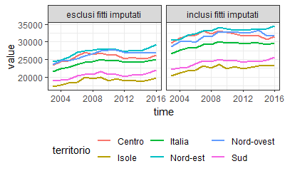

income variation - 2009 to 2016

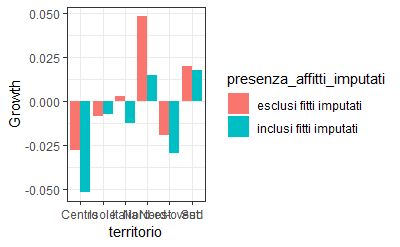

Mean and median income - timeline comparison

[figure not shown]

```r
income.tots %>%
  ggplot(aes(time, value, colour = territorio)) + geom_line(size = 1) +
  theme_bw() +
  facet_wrap( presenza_affitti_imputati ~ tipo_dato) +
  theme(legend.position = 'bottom')
```

Income growth by gender (2009-2016)

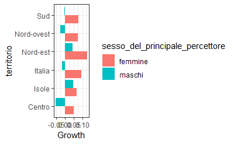

Consumption expenditure for households (ISTAT) https://www.istat.it/it/archivio/spesa+per+consumi

```r
spese.consumi <- read.csv('../Econ data/Spese per consumi - it.csv', sep = '|') %>%
  clean_names()

names(spese.consumi)
```

```
 [1] "i_itter107"
 [2] "territorio"
 [3] "tipo_dato8"
 [4] "tipo_dato"
 [5] "coicop_2015"
 [6] "coicop"
 [7] "coicop_dich"
 [8] "gruppo_di_spesa"
 [9] "quantile"
[10] "quantili_di_spesa_totale_equivalente"
[11] "giudizio_tipo"
[12] "abitudine_di_spesa"
[13] "numerosita"
[14] "ampiezza_familiare"
[15] "tip_fam"
[16] "tipologia_familiare"
[17] "titolo_studio"
[18] "titolo_di_studio_pi_a¹elevato_conseguito_dalla_persona_di_riferimento"
[19] "condizione_dich4"
[20] "condizione_professionale_della_persona_di_riferimento"
[21] "time"
[22] "seleziona_periodo"
[23] "value"
[24] "flag_codes"
[25] "flags"
```

Academic attainment data (correlation socioeconomic status - education - healthcare) https://www.istat.it/it/istruzione-e-formazione

```r
istruzione.italia <- readxl::read_excel('../Econ data/Istruzione.xls', sheet = 'Dati Italia e Regioni', na = c('', '....')) %>%
  clean_names()

istruzione.italia <- istruzione.italia %>%
  gather(key = year, value = value, - c(settore, indicatore, modalita, unita_di_misura, territorio, fonte, note)) %>%
  separate(year, into = c(NA, 'year'), sep = 'x') %>%
  mutate(value = as.numeric(value), year = as.numeric(year)) %>%
  select(indicatore, modalita, year, territorio, value, unita_di_misura, everything())
```

School dropouts (great progress in time, but higher rates in the South)

[figure not shown]

% people 30-34 with university degree (not too high in general, definitely higher in the North)

[figure not shown]

```r
istruzione.italia %>%
  filter(indicatore == '30-34enni con istruzione universitaria') %>%
   ggplot(aes(year, value, colour = modalita)) + geom_line() +
  theme_bw() +
  facet_wrap(.~territorio)
```

[output not shown]

[output cut: 519 more lines]

```r
cancellati.mob <- read.csv('../Econ data/cancellati_mobilita.csv', encoding = 'Latin-1') %>%
  mutate(type = rep('cancellati', nrow(.))) %>%
  gather(key = 'year', value = 'value', -REGIONI, -type) %>%
  separate(year, into = c(NA, 'year'), sep = 'X') %>%
  mutate(year = as.numeric(year))
```

```r
iscritti.mob <- read.csv('../Econ data/iscritti_mobilita.csv', encoding = 'Latin-1') %>%
  mutate(type = rep('iscritti', nrow(.))) %>%
  gather(key = 'year', value = 'value', -REGIONI, -type) %>%
  separate(year, into = c(NA, 'year'), sep = 'X') %>%
  mutate(year = as.numeric(year))
```

Net mobility between regions

```r
saldo.mob <- rbind(iscritti.mob, cancellati.mob) %>%
  spread(type, value) %>%
  mutate(saldo = iscritti - cancellati)
```

```r
ggplot(saldo.mob, aes(year, saldo)) + geom_col() +
  theme_bw() +
  facet_wrap(.~REGIONI)
```

[output not shown]

```r
macro <- c('Nord-ovest', 'Nord-est', 'Centro', 'Sud', 'Isole')
```

Public and household healthcare expenditure (per household) Source: Ambrosetti

| i_it107 | regione | avg | spesa_pubblica | spesa_privata | tot |
| --- | --- | --- | --- | --- | --- |
| ITF1 | Abruzzo | 60.65 | 1801 | 438 | 2239 |
| ITF5 | Basilicata | 54.50 | 1842 | 530 | 2372 |
| ITD1 | Bolzano/Bozen | 70.30 | 2285 | 713 | 2998 |
| ITF6 | Calabria | 52.25 | 1741 | 521 | 2262 |
| ITF3 | Campania | 56.40 | 1729 | 413 | 2142 |
| ITD5 | Emilia-Romagna | 61.35 | 1890 | 758 | 2648 |
| ITD4 | Friuli-Venezia Giulia | 61.20 | 1900 | 674 | 2574 |
| ITE4 | Lazio | 59.05 | 1913 | 679 | 2592 |
| ITC3 | Liguria | 60.45 | 2037 | 683 | 2720 |
| ITC4 | Lombardia | 59.95 | 1861 | 835 | 2696 |

[output cut: 11 more lines]

Let’s merge income data with healthcare expenditure

```r
income.data %>%
  filter(!territorio %in% c('Nord-ovest', 'Nord-est', 'Centro', 'Sud', 'Isole', 'Italia')) %>%
  filter(condizione_professionale_prevalente_nell_anno_del_principale_percettore == 'totale' & titolo_di_studio_del_principale_percettore == 'totale' & fonte_principale_di_reddito_familiare == 'totale' & numero_di_anziani_in_famiglia == 'totale' & numero_di_minori_in_famiglia == 'totale' & classe_di_et_a_del_principale_percettore == 'totale' & sesso_del_principale_percettore == 'totale' & tipologia_familiare == 'totale' & numero_di_componenti == 'totale'& grepl('MEDIANO', t_d8) & time == max(time)) -> for.merge
```

```r
spesa.pc %>%
left_join(., for.merge, by = 'i_it107') -> correlation.df
```

```
Column `i_it107` joining factors with different levels, coercing to character vector
```

[figure not shown]

```r
correlation.df %>%
  filter(grepl('inclusi', presenza_affitti_imputati)) %>%
  ggplot(aes(value, avg, colour = regione, label= regione)) + geom_point() +
  geom_label()
```

```r
# putting together life expectancy, income, healthcare expenditure
nord <- append(nord.est, nord.ovest)
mezzogiorno <- append(sud, isole)
correlation.df %>%
  select(i_it107, territorio, avg, starts_with('spesa'), spesa_privata, tipo_dato, presenza_affitti_imputati, value) -> correlation.df


 # write.csv(correlation.df, '../website/src/age_income.csv', row.names = FALSE)
```